# 2017-09-08-probability

> 08 Sep 2017 » probability, statistics

#### 수식이 깨질 경우 새로고침을 눌러주세요.

## Probability for Data-Science-10

### 확률밀도함수의 독립 (다변량 랜덤 변수에서)

$$ 만약\; 두\; 확률\; 변수\; X,\; Y의\; 결합\; 확률밀도함수가\; 주변\; 확률밀도함수의\; 곱으로\; 나타나면\; 두\; 확률\; 변수가\; 서로\; 독립(independent)이라고\; 한다. $$

$$ f_{XY}(x, \;y) = f_X(x)\;f_Y(y) $$

> 위 식에서 알 수 있듯이, 독립인 경우에는 각각의 주변 확률밀도함수만으로 결합 확률밀도함수가 결정됨.

> X, Y가 독립일 경우, 두 변수 중 하나(예를 들어 Y)가 어떤 값을 갖더라도 확률밀도함수의 모양은 변하지 않는다.

### 동일한 확률 변수에서 N 개의 표본 데이터를 추출하는 경우

> 서로 독립인 N 개의 확률변수에 나온 표본으로 볼 수 있다.

$$ ∴\;\; 확률밀도함수가\; f(x)이고\; 표본\; 데이터가\; \{x_1, x_2, x_3, \cdots, x_N \}이면\; 이 \;데이터\; 집합이\; 나올\; 수\; 있는\; 확률은\; 다음과\; 같다. $$$$ \bbox[7px, border:2px solid blue]{\begin{eqnarray} f_{x_1,x_2,\cdots,x_N} (x_1,x_2,\cdots,x_N) &=& \prod_{i=1}^N f(x_i) \\ &=& f(x_1)\cdot f(x_2) \cdots f(x_{N-1})\cdot f(x_N) \end{eqnarray}} $$$$ X,\; Y의\; 결합확률밀도함수\; f_{x_1,x_2,\cdots,x_N} (x_1,x_2,\cdots,x_N)는\; 각각의\; 주변확률밀도함수의\; 곱으로\; 표현가능하다.$$

### 독립 확률변수의 기대값

> 독립인 두 확률변수 X, Y의 기댓값은 다음 성질을 만족한다. $$ \text{E}[XY] = \text{E}[X]\text{E}[Y] $$

> **Pf)** $$ \begin{eqnarray} \text{E}[XY] &=& \int xy \;f_{XY}(x, y) \; dx dy \\ &=& \int xy \;f_{X}(x)f_{Y}(y) \; dx dy \\ &=& \int x \;f_{X}(x) \; dx \int y \;f_{Y}(y) \; dy \\ &=& \text{E}[X] \text{E}[Y] \\ \end{eqnarray} $$

### 독립 확률변수의 분산

> 독립인 두 확률변수 X, Y의 분산은 다음 성질을 만족한다. $$ \text{Var}[X+Y] = \text{Var}[X] + \text{Var}[Y] $$

> **Pf)** $$ \begin{eqnarray} \text{Var}[X + Y] &=& \text{E}[((X + Y) - (\mu_X + \mu_Y))^2] \\ &=& \text{E}[(X+Y)^2 - 2(X+Y)(\mu_X + \mu_Y) + (\mu_X + \mu_Y)^2] \\ &=& \text{E}[X^2+2XY+Y^2] - 2(\mu_X + \mu_Y)\text{E}[X+Y] + (\mu_X + \mu_Y)^2 \\ &=& \text{E}[X^2+2XY+Y^2] - 2(\mu_X + \mu_Y)^2 + (\mu_X + \mu_Y)^2 \\ &=& \text{E}[X^2]+2\text{E}[XY]+\text{E}[Y^2] - (\mu_X + \mu_Y)^2 \\ &=& \text{E}[X^2]+2\text{E}[X]\text{E}[Y]+\text{E}[Y^2] - (\mu_X^2 + 2\mu_X\mu_Y + \mu_Y^2) \\ &=& \text{E}[X^2]+2\mu_x\mu_y+\text{E}[Y^2] - (\mu_X^2 + 2\mu_X\mu_Y + \mu_Y^2) \\ &=& \text{E}[X^2]+\text{E}[Y^2] - (\mu_X^2 + \mu_Y^2) \\ &=& \text{E}[X^2]-\mu_X^2+\text{E}[Y^2]-\mu_Y^2 \\ &=& \text{Var}[X]+\text{Var}[Y] \\ \end{eqnarray} $$

### 조건부 확률분포

> 독립인 두 확률변수 X, Y의 조건부 확률밀도함수는 주변 확률밀도함수와 같다.

> 독립이므로 다른 사건이 일어나든 말든 상관이 없다.

$$ f_{X \mid Y} (x | y_0) = f_{X}(x) $$

> **Pf)** $$ f_{X \mid Y} (x | y_0) = \dfrac{f_{XY}(x, y=y_0)}{f_{Y}(y_0)} = \dfrac{f_{X}(x) f_{Y}(y_0)}{f_{Y}(y_0)} = f_{X}(x) $$

$$ f_{Y \mid X} (y | x_0) = \dfrac{f_{XY}(x=x_0, y)}{f_{X}(x_0)} = \dfrac{f_{X}(x_0) f_{Y}(y)}{f_{X}(x_0)} = f_{Y}(y) $$

> 확률 변수 X가 다른 확률 변수 Y에 독립이면 조건부 확률 분포가 조건이 되는 확률 변수의 값에 영향을 받지 않는다.

$$ f(x \mid y_1) = f(x \mid y_2) $$

### 다음의 예를 보자.

```python
# -*- coding: utf-8 -*-

import seaborn as sns
import pandas as pd
import scipy as sp
import matplotlib as mpl
import matplotlib.pylab as plt
import numpy as np
%matplotlib inline
sns.set()
sns.set_color_codes()
```

```python
# floating 출력을 몇 자리까지 지정하자. 소수 넷 째자리까지 출력하라.
np.set_printoptions(precision=4)
pmf1 = np.array([[0, 1, 2, 3, 2, 1],
                 [0, 2, 4, 6, 4, 2],
                 [0, 4, 8,12, 8, 4],
                 [0, 2, 4, 6, 4, 2],
                 [0, 1, 2, 3, 2, 1]])
pmf1 = pmf1 / pmf1.sum()
pmf1
```

```
array([[ 0.    ,  0.0111,  0.0222,  0.0333,  0.0222,  0.0111],
       [ 0.    ,  0.0222,  0.0444,  0.0667,  0.0444,  0.0222],
       [ 0.    ,  0.0444,  0.0889,  0.1333,  0.0889,  0.0444],
       [ 0.    ,  0.0222,  0.0444,  0.0667,  0.0444,  0.0222],
       [ 0.    ,  0.0111,  0.0222,  0.0333,  0.0222,  0.0111]])
```

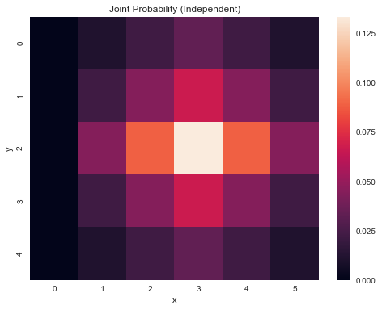

```python
plt.figure(figsize=(8,6))

sns.heatmap(pmf1)
plt.xlabel("x")
plt.ylabel("y")
plt.title("Joint Probability (Independent)")
plt.show()
```

```python
pmf1_marginal_x = pmf1.sum(axis=0)
pmf1_marginal_y = pmf1.sum(axis=1)
pmf = pmf1_marginal_x * pmf1_marginal_y[:, np.newaxis]
pmf
```

```
array([[ 0.    ,  0.0111,  0.0222,  0.0333,  0.0222,  0.0111],
       [ 0.    ,  0.0222,  0.0444,  0.0667,  0.0444,  0.0222],
       [ 0.    ,  0.0444,  0.0889,  0.1333,  0.0889,  0.0444],
       [ 0.    ,  0.0222,  0.0444,  0.0667,  0.0444,  0.0222],
       [ 0.    ,  0.0111,  0.0222,  0.0333,  0.0222,  0.0111]])
```

```python
pmf.sum()
```

```
1.0
```

#### pmf1와 pmf의 값이 같다는 것을 확인할 수 있었다.

> **∴ X와 Y는 서로 독립이다.**

```python
cond_x_y0 = pmf1[0, :]/pmf1_marginal_y[0]
cond_x_y0
```

```
array([ 0.    ,  0.1111,  0.2222,  0.3333,  0.2222,  0.1111])
```

```python
cond_x_y1 = pmf1[1, :]/pmf1_marginal_y[1]
cond_x_y1
```

```
array([ 0.    ,  0.1111,  0.2222,  0.3333,  0.2222,  0.1111])
```

```python
cond_x_y2 = pmf1[2, :]/pmf1_marginal_y[2]
cond_x_y2
```

```
array([ 0.    ,  0.1111,  0.2222,  0.3333,  0.2222,  0.1111])
```

#### X와 Y가 서로 독립이므로, Y 값의 무관하게 X의 pmf는 동일하다.

### 이번에는 다음과 같은 결합 확률 분포를 보자. 이 경우에는 독립 조건이 성립하지 않는다.

```python
pmf2 = np.array([[0, 0, 0, 0, 1, 1],
                 [0, 0, 1, 2, 1, 0],
                 [0, 1, 3, 3, 1, 0],
                 [0, 1, 2, 1, 0, 0],
                 [1, 1, 0, 0, 0, 0]])
pmf2 = pmf2 / pmf2.sum()
pmf2
```

```
array([[ 0.  ,  0.  ,  0.  ,  0.  ,  0.05,  0.05],
       [ 0.  ,  0.  ,  0.05,  0.1 ,  0.05,  0.  ],
       [ 0.  ,  0.05,  0.15,  0.15,  0.05,  0.  ],
       [ 0.  ,  0.05,  0.1 ,  0.05,  0.  ,  0.  ],
       [ 0.05,  0.05,  0.  ,  0.  ,  0.  ,  0.  ]])
```

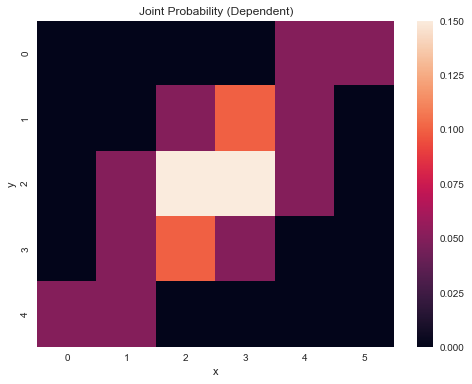

```python
plt.figure(figsize=(8,6))

sns.heatmap(pmf2)
plt.xlabel("x")
plt.ylabel("y")
plt.title("Joint Probability (Dependent)")
plt.show()
```

```python
pmf2_marginal_x = pmf2.sum(axis=0)
pmf2_marginal_y = pmf2.sum(axis=1)
pmf2_mul = pmf2_marginal_x * pmf2_marginal_y[:, np.newaxis]
pmf2_mul
```

```
array([[ 0.005,  0.015,  0.03 ,  0.03 ,  0.015,  0.005],
       [ 0.01 ,  0.03 ,  0.06 ,  0.06 ,  0.03 ,  0.01 ],
       [ 0.02 ,  0.06 ,  0.12 ,  0.12 ,  0.06 ,  0.02 ],
       [ 0.01 ,  0.03 ,  0.06 ,  0.06 ,  0.03 ,  0.01 ],
       [ 0.005,  0.015,  0.03 ,  0.03 ,  0.015,  0.005]])
```

```python
pmf2
```

```
array([[ 0.  ,  0.  ,  0.  ,  0.  ,  0.05,  0.05],
       [ 0.  ,  0.  ,  0.05,  0.1 ,  0.05,  0.  ],
       [ 0.  ,  0.05,  0.15,  0.15,  0.05,  0.  ],
       [ 0.  ,  0.05,  0.1 ,  0.05,  0.  ,  0.  ],
       [ 0.05,  0.05,  0.  ,  0.  ,  0.  ,  0.  ]])
```

#### marginal 함수의 곱과 X,Y의 결합 확률밀도함수가 다르다는 것을 알 수 있다.

> **∴ X와 Y는 서로 독립이 아니다. 종속관계이다.**

```python
cond_x_y0 = pmf2[0, :]/pmf2_marginal_y[0]
cond_x_y0
```

```
array([ 0. ,  0. ,  0. ,  0. ,  0.5,  0.5])
```

```python
cond_x_y1 = pmf2[1, :]/pmf2_marginal_y[1]
cond_x_y1
```

```
array([ 0.  ,  0.  ,  0.25,  0.5 ,  0.25,  0.  ])
```

```python
cond_x_y2 = pmf2[2, :]/pmf2_marginal_y[2]
cond_x_y2
```

```
array([ 0.   ,  0.125,  0.375,  0.375,  0.125,  0.   ])
```

> 두 확률 변수가 독립이 아닌 경우, 두 확률 변수가 서로 **의존(dependent)**한다고 한다.

> Share this on → [Tweet](https://twitter.com/share)

#### Related Posts

> « Python basic (List & Dictionary) 공분산과 상관계수 »